# Poverty and Economic Decision-Making

Do changes in one’s financial circumstances affect one’s decision-making process and cognitive capacity? In an experimental study, researchers randomly selected a group of US respondents to be surveyed before their payday and another group to be surveyed after their payday. Under this design, the respondents of the `Before Payday` group are more likely to be financially strained than those of the `After Payday` group. The researchers were interested in investigating whether or not changes in people’s financial circumstances affect their decision making and cognitive performance. Other researchers have found that scarcity induce an additional mental load that impedes cognitive capacity. This exercise is based on:

Carvalho, Leandro S., Meier, Stephen, and Wang, Stephanie W. (2016). “[Poverty and economic decision-making: Evidence from changes in financial resources at payday.](http://dx.doi.org/10.1257/aer.20140481)” *American Economic Review*, Vol. 106, No. 2, pp. 260-284.

In this study, the researchers administered a number of decision-making and cognitive performance tasks to the `Before Payday` and `After Payday` groups. We focus on the *numerical stroop task*, which measures cognitive control. In general, taking more time to complete this task indicates less cognitive control and reduced cognitive ability. They also measured the amount of cash the respondents have, the amount in their checking and saving accounts, and the amount of money spent. The data set is in the CSV file `poverty.csv`. The names and descriptions of variables are given below:

| Name | Description |
| --- | --- |
| `treatment` | Treatment conditions: `Before Payday` and `After Payday` |
| `cash` | Amount of cash respondent has on hand |
| `accts_amt` | Amount in checking and saving accounts |
| `stroop_time` | Log-transformed average response time for cognitive stroop test |
| `income_less20k` | Binary variable: `1` if respondent earns less than 20k a year and `0` otherwise |

## Question 1

Load the `poverty.csv` data set. Use histograms to examine the univariate distributions of the two financial resources measures: `cash` and `accts_amt`. What can we tell about these variables’ distributions from looking at the histograms? Evaluate what the shape of these distributions could imply for the authors’ experimental design.

Financial variables with lots of observations drawn from large populations are prone to outliers, and these outliers can sometimes obscure the analysis of such variables. To handle this phenomenon, we can take the *natural logarithm* of `cash` and `accts_amt` using the `log()` function, a mathematical transformation that helps decrease the amount of variation in the `cash` and `accts_amt` variables. Create a log transformed version of both variables and plot their histograms. How does the distribution look now? What are the disadvantages of transforming the data in this way?

**NOTE:** Since the natural logarithm of 0 is undefined, researchers often add a small value (in this case, we will use $1 so that $\log 1 = 0$) to the 0 values for the variables being transformed (in this case, `cash` and `accts_amt`) in order to successfully apply the `log()` function to all values. Be sure to do this recoding only for the purposes of taking the logarithmic transformation – keep the original variables the same.

## Answer 1

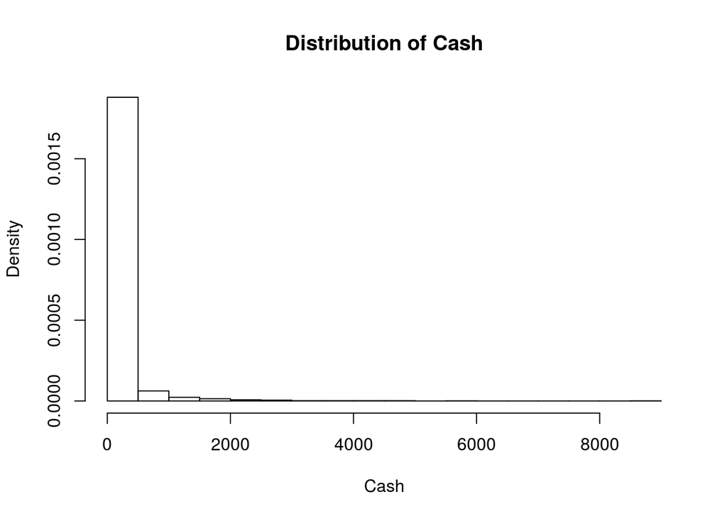

```r
poverty <- read.csv("data/poverty.csv")
hist(poverty$cash, freq = FALSE, xlab = "Cash", main = "Distribution of Cash")
```

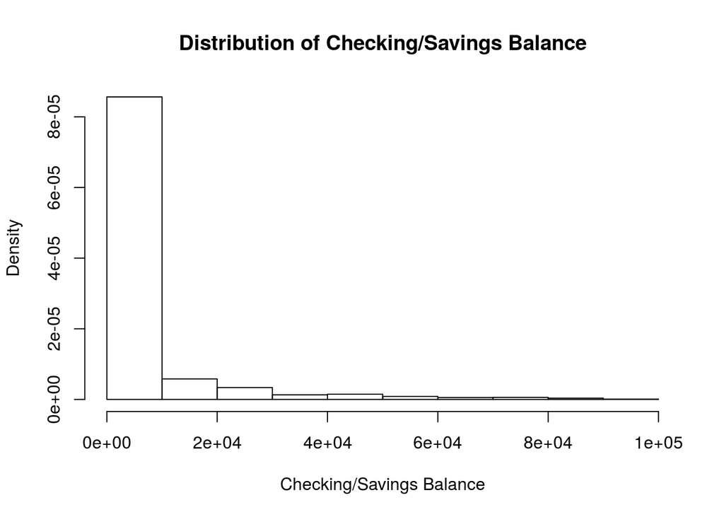

```r
hist(poverty$accts_amt, freq = FALSE, xlab = "Checking/Savings Balance",
     main = "Distribution of Checking/Savings Balance")
```

The distributions of the `cash`, and `accts_amt` variables are all highly skewed and possess many extreme values (outliers). These extreme values could pull our mean estimates upward, causing us to overestimate the mean amount of cash, as well as amount in checking and saving accounts for our sample. If these outliers are not evenly distributed between `BeforeTreatment` and `AfterTreatment` groups, we could also mischaracterize the effect of change in financial resources on decision-making. This would hamper the authors’ ability to make a causal claim about this effect by hurting the internal validity of the survey experiment.

[figure not shown]

```r
poverty$log_cash <- poverty$cash
poverty$log_cash[poverty$log_cash == 0] <- 1
poverty$log_cash <- log(poverty$log_cash)

poverty$log_accts_amt <- poverty$accts_amt
poverty$log_accts_amt[poverty$log_accts_amt == 0] <- 1
poverty$log_accts_amt <- log(poverty$log_accts_amt)

hist(poverty$log_cash, freq = FALSE, xlab = "log(Cash)",
     main = "Distribution of log(Cash) After Payday")
```

[figure not shown]

```r
hist(poverty$log_accts_amt, freq = FALSE,
     xlab = "log(Checking/Savings Balance)",
     main = "Distribution of log(Checking/Savings)\n Balance After Payday")
```

The distribution is now noticeably less skewed, although it is harder to interpret the values of the variables since everything is now on a log scale.

## Question 2

Now, let’s examine the primary outcome of interest for this study–the effect of a change in financial situation (in this case, getting paid on payday) on economic decision-making and cognitive performance. Begin by calculating the treatment effect for the `stroop_time` variable (a log-transformed variable of the average response time for the stroop cognitive test), using first the mean and then the median. What does this tell you about differences in the outcome across the two experimental conditions?

Secondly, let’s look at the relationship between finanical circumstances and the cognitive test variable. Produce two scatter plots, one for each of the two experimental conditions, showing the bivariate relationship between your *log-transformed* `cash` variable and the amount of time it took subjects to complete the stroop cognitive test administered in the survey (`stroop_time`). Place the `stroop_time` variable on the y-axis. Be sure to title your graphs to differentiate between the `Before Payday` and `After Payday` conditions. Now do the same for the *log-transformed* `accts_amt` variable.

Briefly comment on your results in light of the hypothesis that changes in economic circumstances will influence cognitive performance.

## Answer 2

```r
mean(poverty$stroop_time[poverty$treatment == "After Payday"]) -
  mean(poverty$stroop_time[poverty$treatment == "Before Payday"])
```

```
## [1] 0.01142325
```

```r
median(poverty$stroop_time[poverty$treatment == "After Payday"]) -
  median(poverty$stroop_time[poverty$treatment == "Before Payday"])
```

```
## [1] 0.01430528
```

Because mean and median cognitive scores are very similar for the two groups, the average and median treatment effects are close to zero.

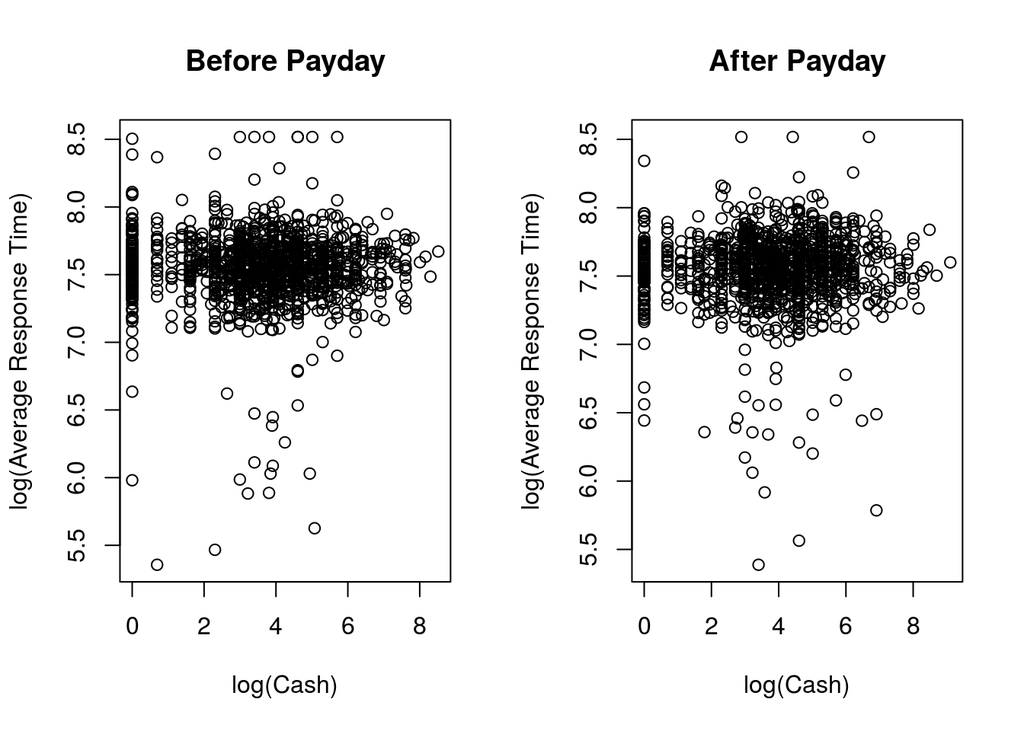

```r
par(mfrow = c(1,2))

plot(poverty$log_cash[poverty$treatment == "Before Payday"],
     poverty$stroop_time[poverty$treatment == "Before Payday"],
     ylab = "log(Average Response Time)", xlab = "log(Cash)", main = "Before Payday")

plot(poverty$log_cash[poverty$treatment == "After Payday"],
     poverty$stroop_time[poverty$treatment == "After Payday"],
     ylab = "log(Average Response Time)", xlab = "log(Cash)", main = "After Payday")
```

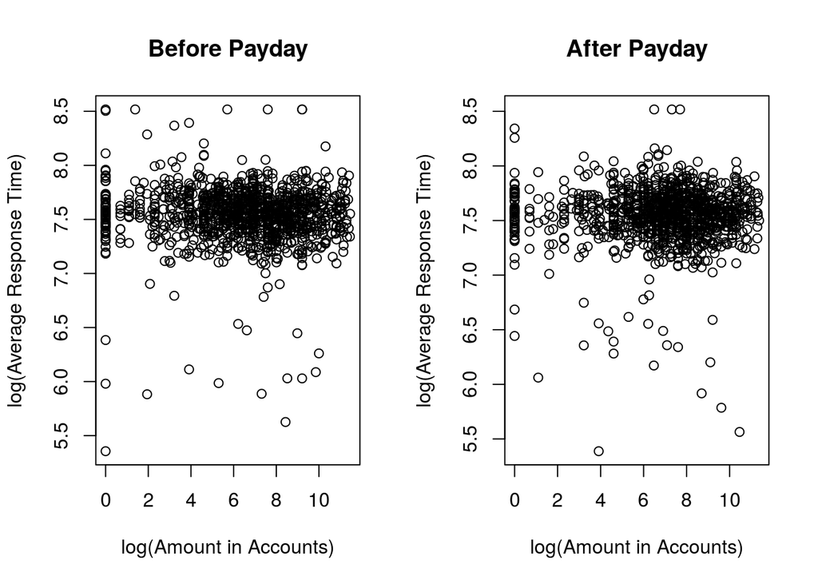

```r
plot(poverty$log_accts_amt[poverty$treatment == "Before Payday"],
     poverty$stroop_time[poverty$treatment == "Before Payday"],
     ylab = "log(Average Response Time)", xlab = "log(Amount in Accounts)", main ="Before Payday")

plot(poverty$log_accts_amt[poverty$treatment == "After Payday"],
     poverty$stroop_time[poverty$treatment == "After Payday"],
     ylab = "log(Average Response Time)", xlab = "log(Amount in Accounts)",
     main = "After Payday")
```

By looking at the scatter plots we can see that the relationship between financial circumstances (both cash on hand and amount in accounts), and cognitive performance (as indicated by the amount of time it took respondents to do the stroop test) is essentially flat for both before and after payday groups. This suggests that changes in financial resources do *not* affect cognitive performance.

## Question 3

Now, let’s take a closer look at whether or not the `Before Payday` versus `After Payday` treatment created measurable differences in financial circumstances. What is the effect of payday on participants’ financial resources? Tohelp with interpretability, use the original variables `cash` and `accts_amt` to calculate this effect. Calculate both the mean and median effect. Does the measure of central tendency you use affect your perception of the effect?

## Answer 3

```r
cashmean.diff <- mean(poverty$cash[poverty$treatment == "After Payday"], na.rm = TRUE) -
  mean(poverty$cash[poverty$treatment == "Before Payday"], na.rm = TRUE)

cashmed.diff <- median(poverty$cash[poverty$treatment == "After Payday"], na.rm = TRUE) -
  median(poverty$cash[poverty$treatment == "Before Payday"], na.rm = TRUE)

cashmean.diff
```

```
## [1] 36.77511
```

```r
cashmed.diff
```

```
## [1] 10
```

```r
balancemean.diff <- mean(poverty$accts_amt[poverty$treatment == "After Payday"], na.rm = TRUE) -
  mean(poverty$accts_amt[poverty$treatment == "Before Payday"], na.rm = TRUE)

balancemed.diff <- median(poverty$accts_amt[poverty$treatment == "After Payday"], na.rm = TRUE) -
  median(poverty$accts_amt[poverty$treatment == "Before Payday"], na.rm = TRUE)

balancemean.diff
```

```
## [1] -251.9087
```

```r
balancemed.diff
```

```
## [1] 450
```

After payday, respondents report on average 251.91 dollars *less* in their checking and savings than before payday. The median difference, however, indicates that respondents have 450 *more* dollars in their checking and savings account. This large diffence between the two values suggests the presence of influential outliers unevenly distributed between before and after payday groups.

## Question 4

Compare the distributions of the `Before Payday` and `After Payday` groups for the *log-transformed* `cash` and `accts_amt` variables. Use histograms to make this comparison. Briefly interpret your results and their implications for the authors’ argument that their study generated variation in financial resources before and after payday.

## Answer 4

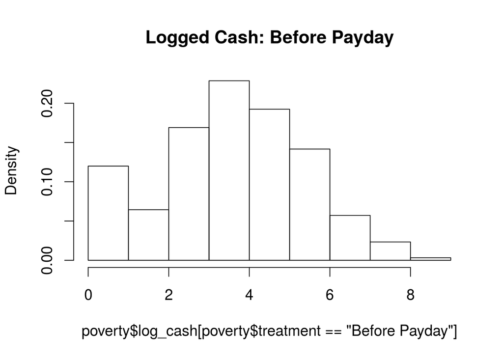

```r
par(cex = 1.25)
hist(poverty$log_cash[poverty$treatment == "Before Payday"], freq = FALSE, main = "Logged Cash: Before Payday")
```

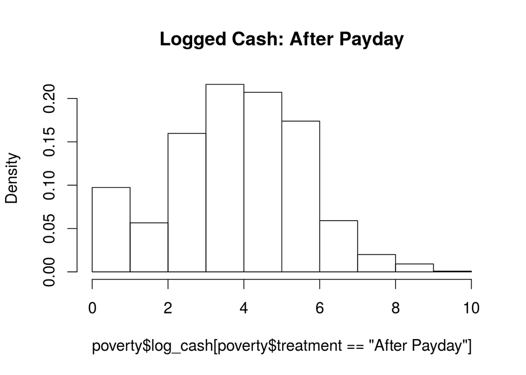

```r
hist(poverty$log_cash[poverty$treatment == "After Payday"], freq = FALSE, main = "Logged Cash: After Payday")
```

Despite a slight difference in length of their right tails, both histograms are quite similar to one another. This suggests that there are no major differences in the distribution of cash held by respondents `Before Payday` and `After Payday`. This could be a problem for the authors’ argument because cash is one of the measures of financial resources the authors use. If there is no variation in cash after payday anywhere in the distribution, the treatment did not occur.

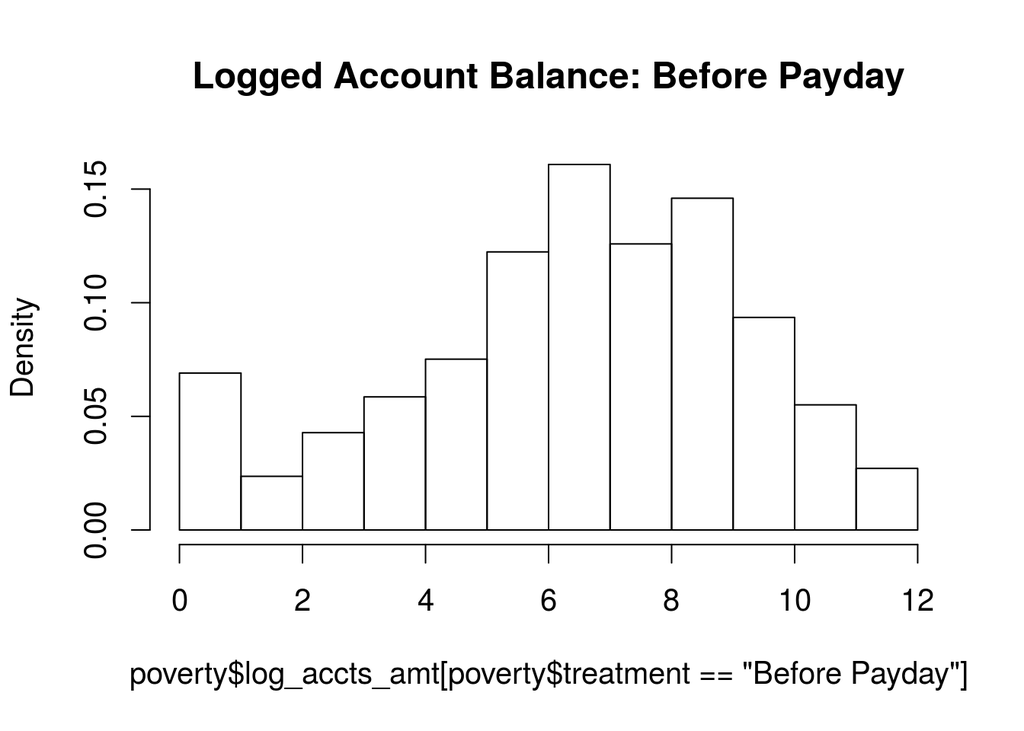

```r
par(cex = 1.25)
hist(poverty$log_accts_amt[poverty$treatment == "Before Payday"], freq = FALSE, main = "Logged Account Balance: Before Payday")
```

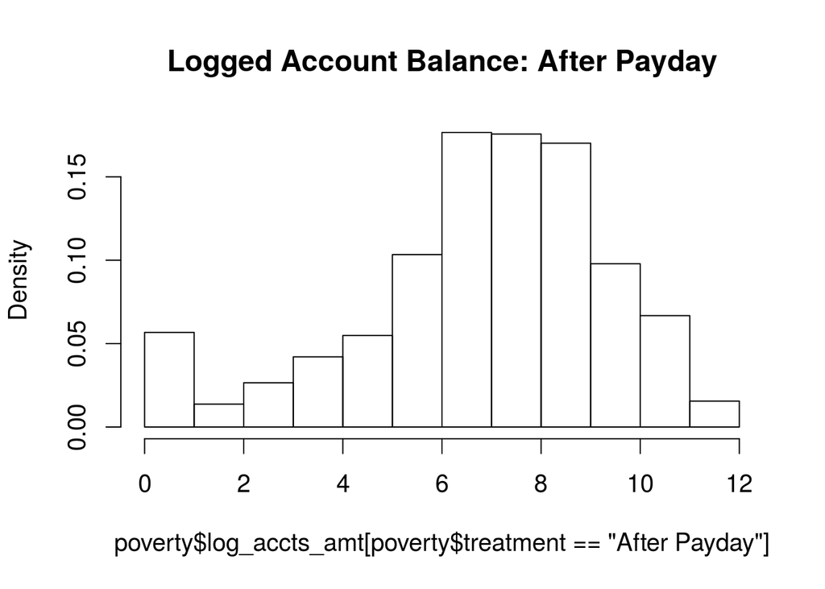

```r
hist(poverty$log_accts_amt[poverty$treatment == "After Payday"], freq = FALSE, main = "Logged Account Balance: After Payday")
```

While after payday respondents on the low end of the log account balance distribution seem to have more money in checking and savings accounts than those before payday, the high end of the respective respondent distributions look relatively similar to one another. If these differences are systematically associated with a pre-treatment variable, this would suggest that there is a heterogeneous effect of payday on checking and savings account balances. This could be a problem for the authors’ argument because checking and savings account balance is one of the measures of financial resources they use. If there is no difference in checking and savings account balances for `Before Payday` and `After Payday`, this means that treatment did not take. Given this heterogeneous treatment effect, we can only test the authors’ hypotheses about the relationship between changes in financial resources and decision-making/cognitive performance for some of the respondents–those most likely to be at the lower end of the `accts_amt` variable’s distribution. Unfortunately, if those respondents are systematically different from respondents most likely to be at the upper end of the accts_amt variable’s distribution, this could put the study’s internal validity in question.

## Question 5

Compare average treatment effects across different ranges of a *pre-treatment variable*–a variable that asks about people’s circumstances before the treatment and thus could not be affected by the treatment. This is known as *heterogeneous treatment effects*–the idea that the treatment may have differential effects for different subpopulations. Let’s look at the pre-treatment variable `income_less20k`. Calculate the treatment effect of Payday on amount in checking and savings accounts separately for respondents earning more than 20,000 dollars a year and those earning less than 20,000 dollars. Use the original `accts_amt` variable for this calculation. What does this comparison tell you about how payday affects the amount that people have in their accounts? Are you convinced by the authors’ main finding from Question 2 in light of your investigation of their success in manipulating cash and account balances before and after payday?

## Answer 5

```r
great20k_diff <- mean(poverty$accts_amt[poverty$income_less20k == 0 &
                                          poverty$treatment == "After Payday"], na.rm = TRUE) -
  mean(poverty$accts_amt[poverty$income_less20k == 0 &
                           poverty$treatment == "Before Payday"], na.rm = TRUE)

less20k_diff <- mean(poverty$accts_amt[poverty$income_less20k == 1 &
                                         poverty$treatment == "After Payday"], na.rm = TRUE) -
  mean(poverty$accts_amt[poverty$income_less20k == 1 &
                           poverty$treatment == "Before Payday"], na.rm = TRUE)
income_diffs <- c(great20k_diff, less20k_diff)
names(income_diffs) <- c("income > 20,000", "income < 20,000")
income_diffs
```

```
## income > 20,000 income < 20,000
##       -649.9476         81.0914
```

```r
diff_diff <- great20k_diff - less20k_diff
diff_diff
```

```
## [1] -731.039
```

We see that the effect of treatment on the amount in people’s accounts is quite different for the lower income group compared to the higher income group. For the lower income group, we see that the effect of treatment is positive–people in the `After Payday` group have a higher balance in their accounts than people in the `Before Payday` group (the difference is 81.09. But for the higher income group, the effect of treatment appears to be negative–those in the After Payday group have 649.95 less than those in the Before Payday group. This brings into question the idea that the study successfully manipulated economic resources through their design, especially for higher income individuals.